# Unraveling Academic Outcomes: The Effects of Unemployment Rate on academic outcomes and Semester Grades

Project 3

Student Name: Yilin Li | SID: 530536402

The University of Sydney | DATA1001 | 26/10/2023

# 1 Client Bio & Recommendation

## 1.1 Client Bio

#### [StudyAssist](https://www.studyassist.gov.au/)

StudyAssist is an Australian Government project aimed at aiding students in their pursuit of higher education. They provide information about government loans and student financial support programmes.

## 1.2 Recommendation

Given that the aim of StudyAssist is to assist students, it is critical that they take use of the current report’s insights concerning the relationship between unemployment and student academic progress. StudyAssist can improve their grant programmes to better suit the requirements of students in high-unemployment areas by better understanding these links. This data-driven method increases their outreach efforts and ensures that students from challenging backgrounds are aware of the assistance available to them. This not only increases StudyAssist’s position as an educational ally, but also ensures that more students get the help they require.

# 2 Evidence

## 2.1 Initial Data Analysis (IDA)

This study examines data from the Polytechnic Institute of Portalegre, available on [Kaggle](https://www.kaggle.com/datasets/thedevastator/higher-education-predictors-of-student-retention?resource=download), focusing on undergraduate enrollees. Data of significant research significance will be used in this report for the study due to the reasonably broad coverage of the data.

Central to this analysis is the unemployment rate within the students’ socioeconomic context, which will be juxtaposed against:

- Relationship between unemployment rate and academic outcomes
- Relationship between unemployment rate and second-semester curricular unit grades

In addition, the unemployment rate and second-semester unit grades are continuous data, and the target data type (which is employed to analyse academic outcomes) is categorical. To investigate the association of the factors, the photos were shown using a stacked bar plot and linear regression.

## 2.2 Relationship between unemployment rate & academic outcomes

Academic outcomes are derived from data on graduated, dropped-out, and currently enrolled students. Considering potential skewness from recently enrolled students, the analysis will exclusively scrutinize the correlation between unemployment rates at data collection and the outcomes of graduates and dropouts.

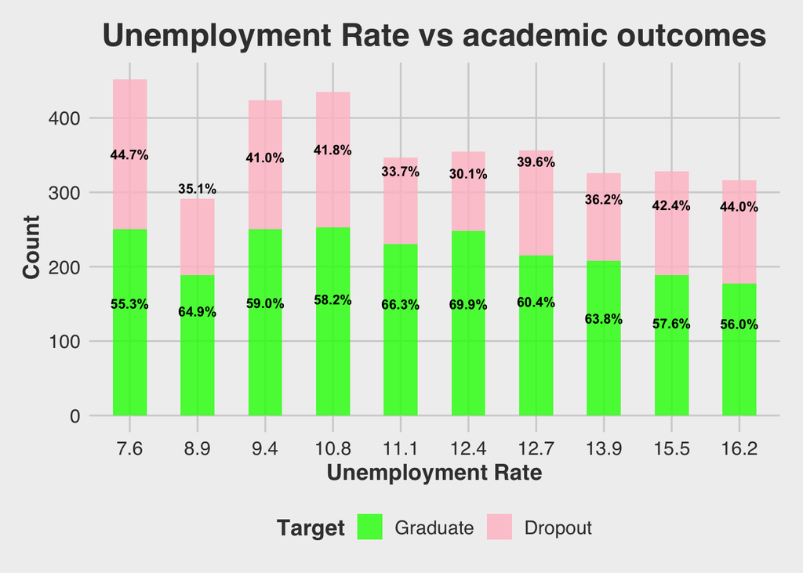

```r
students <- read_csv("students.csv")
students <- students %>%
  filter(Target %in% c("Graduate", "Dropout")) %>%
  arrange(`Unemployment rate`)

# Calculate the count and percentage for each group
students_sum <- students %>%
  group_by(`Unemployment rate`, Target) %>%
  summarise(count = n()) %>%
  mutate(percentage = count / sum(count) * 100)

ggplot(students_sum, aes(x=factor(`Unemployment rate`, levels = unique(`Unemployment rate`)), y=count, fill=Target)) +
  geom_bar(stat="identity", position="stack", width=0.5, color=NA) + # Remove black frame by setting color to NA
  geom_text(aes(label=sprintf("%.1f%%", percentage), y=ifelse(Target=="Dropout", count/2, count + (count[Target=="Dropout"] / 2))), position=position_stack(vjust=0.5), size=3, color="black", fontface="bold") +
  scale_fill_manual(values=c("Dropout"=scales::alpha("pink", 0.8), "Graduate"=scales::alpha("green", 0.8))) +
  labs(title="Unemployment Rate vs academic outcomes", x="Unemployment Rate", y="Count") +
  theme_fivethirtyeight() + # Use the FiveThirtyEight theme
  theme(
    plot.title = element_text(size=20, hjust=0.5),
    axis.title.x = element_text(size=14, face="bold"),
    axis.title.y = element_text(size=14, face="bold"),
    axis.text.x = element_text(size=12),
    axis.text.y = element_text(size=12),
    legend.title = element_text(size=14, face="bold"),
    legend.text = element_text(size=12)
  ) +
  guides(fill=guide_legend(reverse=TRUE))
```

## 2.3 Relationship between unemployment rate & 2nd semester curricular units grade

Data from students’ second semester grades are evaluated herein. As posited earlier, second semester metrics offer enhanced validity, accounting for new students’ acclimatization to semester dynamics. Furthermore, this segment disaggregates and assesses students based on distinct academic statuses.

### 2.3.1 Linear Regression Plots

#### 2.3.1.1 Graduated students

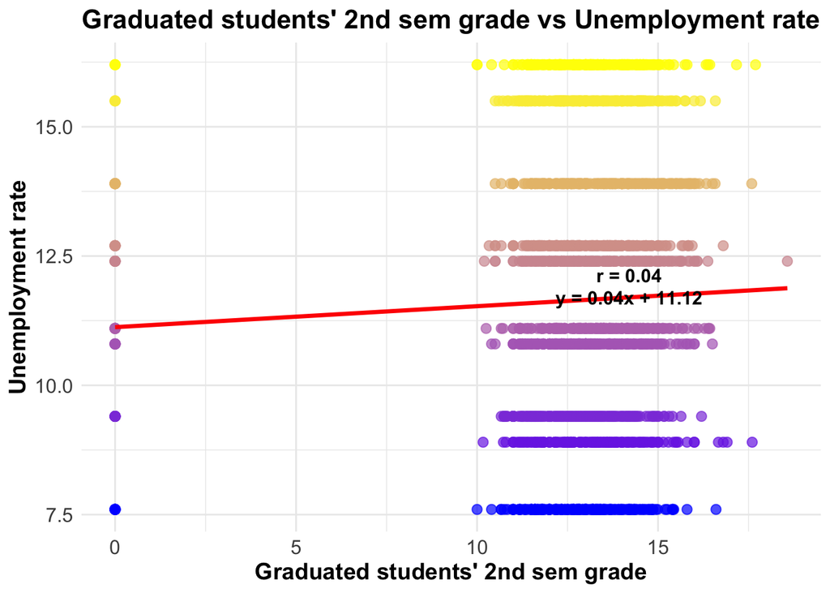

```r
students <- read_csv("students.csv")
students <- students %>%
  filter(Target == "Graduate")

x = students$`Curricular units 2nd sem (grade)`
y = students$`Unemployment rate`

# Calculate linear model and correlation
lm_model <- lm(y ~ x)
cor_value <- cor(x, y)

# Extract coefficients from the linear model
lm_coef <- coef(lm_model)

# Label for linear function
label_eq <- sprintf("y = %.2fx + %.2f", lm_coef[2], lm_coef[1])

# Label for correlation
label_cor <- sprintf("r = %.2f", cor_value)

# Define a position for the labels based on quantiles and predicted values
x_pos <- quantile(x, 0.8)
y_pos_eq <- predict(lm_model, newdata = data.frame(x = x_pos))
y_pos_cor <- y_pos_eq + diff(range(y)) * 0.05

# Enhanced plot
ggplot(students, aes(x, y)) +
  geom_point(aes(color = y), size = 2.5, alpha = 0.7) +
  geom_smooth(method = "lm", se = FALSE, color = "red", aes(group = 1), size = 1.2) +
  annotate("text", x = x_pos, y = y_pos_eq, label = label_eq, col = "black", size = 4, fontface = "bold") +
  annotate("text", x = x_pos, y = y_pos_cor, label = label_cor, col = "black", size = 4, fontface = "bold") +
  scale_color_gradient(low = "blue", high = "yellow") +
  theme_minimal() +
  theme(
    legend.position = "none",
    plot.title = element_text(hjust = 0.5, size = 16, face = "bold"),
    axis.title.x = element_text(size = 14, face = "bold"),
    axis.title.y = element_text(size = 14, face = "bold"),
    axis.text = element_text(size = 12)
  ) +
  labs(
    title = "Graduated students' 2nd sem grade vs Unemployment rate",
    x = "Graduated students' 2nd sem grade",
    y = "Unemployment rate"
  )
```

#### 2.3.1.2 Enrolled students

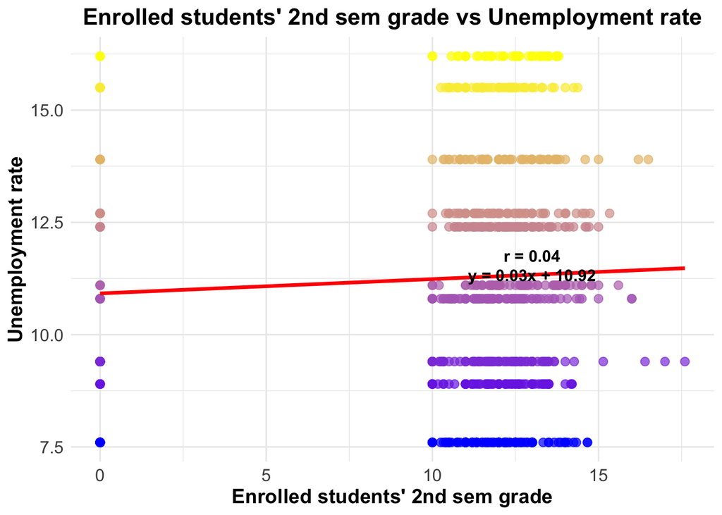

```r
students <- read_csv("students.csv")
students <- students %>%
  filter(Target == "Enrolled")

x = students$`Curricular units 2nd sem (grade)`
y = students$`Unemployment rate`

# Calculate linear model and correlation
lm_model <- lm(y ~ x)
cor_value <- cor(x, y)

# Extract coefficients from the linear model
lm_coef <- coef(lm_model)

# Label for linear function
label_eq <- sprintf("y = %.2fx + %.2f", lm_coef[2], lm_coef[1])

# Label for correlation
label_cor <- sprintf("r = %.2f", cor_value)

# Define a position for the labels based on quantiles and predicted values
x_pos <- quantile(x, 0.8)
y_pos_eq <- predict(lm_model, newdata = data.frame(x = x_pos))
y_pos_cor <- y_pos_eq + diff(range(y)) * 0.05

# Enhanced plot
ggplot(students, aes(x, y)) +
  geom_point(aes(color = y), size = 2.5, alpha = 0.7) +
  geom_smooth(method = "lm", se = FALSE, color = "red", aes(group = 1), size = 1.2) +
  annotate("text", x = x_pos, y = y_pos_eq, label = label_eq, col = "black", size = 4, fontface = "bold") +
  annotate("text", x = x_pos, y = y_pos_cor, label = label_cor, col = "black", size = 4, fontface = "bold") +
  scale_color_gradient(low = "blue", high = "yellow") +
  theme_minimal() +
  theme(
    legend.position = "none",
    plot.title = element_text(hjust = 0.5, size = 16, face = "bold"),
    axis.title.x = element_text(size = 14, face = "bold"),
    axis.title.y = element_text(size = 14, face = "bold"),
    axis.text = element_text(size = 12)
  ) +
  labs(
    title = "Enrolled students' 2nd sem grade vs Unemployment rate",
    x = "Enrolled students' 2nd sem grade",
    y = "Unemployment rate"
  )
```

#### 2.3.1.3 Dropout students

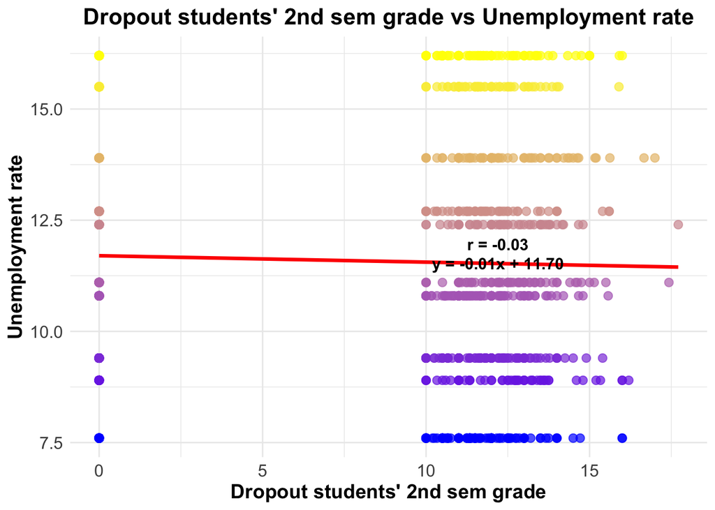

```r
students <- read_csv("students.csv")
students <- students %>%
  filter(Target == "Dropout")

x = students$`Curricular units 2nd sem (grade)`
y = students$`Unemployment rate`

# Calculate linear model and correlation
lm_model <- lm(y ~ x)
cor_value <- cor(x, y)

# Extract coefficients from the linear model
lm_coef <- coef(lm_model)

# Label for linear function
label_eq <- sprintf("y = %.2fx + %.2f", lm_coef[2], lm_coef[1])

# Label for correlation
label_cor <- sprintf("r = %.2f", cor_value)

# Define a position for the labels based on quantiles and predicted values
x_pos <- quantile(x, 0.8)
y_pos_eq <- predict(lm_model, newdata = data.frame(x = x_pos))
y_pos_cor <- y_pos_eq + diff(range(y)) * 0.05

# Enhanced plot
ggplot(students, aes(x, y)) +
  geom_point(aes(color = y), size = 2.5, alpha = 0.7) +
  geom_smooth(method = "lm", se = FALSE, color = "red", aes(group = 1), size = 1.2) +
  annotate("text", x = x_pos, y = y_pos_eq, label = label_eq, col = "black", size = 4, fontface = "bold") +
  annotate("text", x = x_pos, y = y_pos_cor, label = label_cor, col = "black", size = 4, fontface = "bold") +
  scale_color_gradient(low = "blue", high = "yellow") +
  theme_minimal() +
  theme(
    legend.position = "none",
    plot.title = element_text(hjust = 0.5, size = 16, face = "bold"),
    axis.title.x = element_text(size = 14, face = "bold"),
    axis.title.y = element_text(size = 14, face = "bold"),
    axis.text = element_text(size = 12)
  ) +
  labs(
    title = "Dropout students' 2nd sem grade vs Unemployment rate",
    x = "Dropout students' 2nd sem grade",
    y = "Unemployment rate"
  )
```

The graph demonstrates the association between second-semester grades and unemployment rates for graduated, current, and dropout students. Notably, higher unemployment rates appear to coincide with better scores for both current and graduated students, implying a probable link between academic achievement and economic position. With r values of 0.04 for both the graduated and enrolled groups, this link is small but positive.These data point to the nuanced nature of the link between educational attainment and unemployment.

# 3 Testing

### 3.0.1 Linear Modelling

Depending on the variables type, the use of linear modelling provides a clear explanation of relationships and aids in measuring projected outcomes and testing hypotheses. As a result, the ‘HATPC’ method will be used to test the relationship between the unemployment rate and each target type students’ second-semester curricular unit grades. And in here shows the ‘HATPC’ steps for graduated students:

#### H - Hypothesis

- H0: There’s no linear correlation between the unemployment rate and the second-semester grades of graduated students.
- H1: There’s a linear correlation between the unemployment rate and the second-semester grades of graduated students.

#### A - Assumptions

1. We assume that the sample of 2209 students out of 4424 is randomly selected.
2. The relationship between the two variables should be linear.
3. Each pair of variables is independent.

#### T - Test statistic

```r
# Load necessary libraries
library(readr)
library(dplyr)

# Read the CSV file
students <- read_csv("students.csv")

# Count occurrences of each category in the 'Target' column
status_counts <- table(students$Target)

# Extract specific counts
num_graduated <- status_counts['Graduate']
num_Enrolled <- status_counts['Enrolled']
num_Dropout <- status_counts['Dropout']
```

```r
calculate_t_statistic <- function(r, n) {
  numerator <- r * sqrt(n - 2)
  denominator <- sqrt(1 - r^2)

  t <- numerator / denominator

  cat("t =", t, "\n")
}

r_value <- 0.04 #given in evidence linear plot
t_statistic_result <- calculate_t_statistic(r_value, as.numeric(num_graduated))
```

```
## t = 1.880654
```

#### P - P-value

- The P-values in this section are based on those produced with the [sociostatistics](https://www.socscistatistics.com/pvalues/tdistribution.aspx) calculator.
- The P-value is approximately equal to 0.03.

#### C - Conclusion

Based on the p-value = 0.03 < 0.05:

- H0 is rejected;
- There’s a linear correlation between the unemployment rate and the second-semester grades of graduated students.

#### Similar as above steps, for the other two categories:

Dropout students:

```r
calculate_t_statistic <- function(r, n) {
  numerator <- r * sqrt(n - 2)
  denominator <- sqrt(1 - r^2)

  t <- numerator / denominator

  cat("t =", t, "\n")
}

r_value <- -0.03 # given in evidence linear plot
num_Dropout <- 60 # You need to provide this value or retrieve it from your data
t_statistic_result <- calculate_t_statistic(r_value, as.numeric(num_Dropout))
```

```
## t = -0.2285761
```

Enrolled students:

```r
calculate_t_statistic <- function(r, n) {
  numerator <- r * sqrt(n - 2)
  denominator <- sqrt(1 - r^2)

  t <- numerator / denominator

  cat("t =", t, "\n")
}

r_value <- 0.04 #given in evidence linear plot
t_statistic_result <- calculate_t_statistic(r_value, as.numeric(num_Enrolled))
```

```
## t = 1.126601
```

- p-value = 0.13 > 0.05
- Conclusion: There’s no a linear correlation between the unemployment rate and the second-semester grades of enrolled students.

### 3.0.2 2-sample T-test

A 2-sample t-test can be performed to investigate the association between the unemployment rate and academic outcomes. This test is extremely relevant since it compares the means of unemployment rates for two different academic outcomes (graduated and dropout). It is possible to determine if unemployment rates affect academic outcomes by analysing the significant difference between two variables. This possible link is nicely demonstrated by the use of a 2-sample t-test.

#### H - Hypothesis

- H0: The mean unemployment rate is the same for both academic outcome groups.
- H1: The mean unemployment rate is different for the two academic outcome groups.

#### A - Assumptions

1. The two samples are independent of each other.
2. The data for unemployment rate in both groups are approximately normally distributed.
3. The variances of unemployment rate in the two groups are equal.

#### T - Test statistic

```r
library(readr)

students <- read_csv("students.csv")

# Extracting unemployment rates for the two groups
unemployment_graduate <- students$`Unemployment rate`[students$Target == 'Graduate']
unemployment_dropout <- students$`Unemployment rate`[students$Target == 'Dropout']

# Calculating the means
mean_unemployment_graduate_rate <- mean(unemployment_graduate, na.rm = TRUE)
mean_unemployment_dropout_rate <- mean(unemployment_dropout, na.rm = TRUE)

# Calculating the standard deviations
SD1 <- sd(unemployment_graduate, na.rm = TRUE)
SD2 <- sd(unemployment_dropout, na.rm = TRUE)

# Calculating the pooled variance
n1 <- length(unemployment_graduate)
n2 <- length(unemployment_dropout)
pooled_variance <- ((n1 - 1) * SD1^2 + (n2 - 1) * SD2^2) / (n1 + n2 - 2)

# Calculating the standard error
SE <- sqrt(pooled_variance / n1 + pooled_variance / n2)

# Calculating the t-statistic
t <- (mean_unemployment_graduate_rate - mean_unemployment_dropout_rate) / SE

cat("test statistic = ", t, "\n")
```

```
## test statistic =  0.2528662
```

#### P - P-value

- The P-value is approximately equal to 0.40.

#### C - Conclusion

Based on the p-value = 0.40 > 0.05:

- H1 is rejected;
- Conclusion: The mean unemployment rate is the same for both academic outcome groups.

# 4 Acknowledgments

- Realinho, V., Machado, J., Baptista, L. and Martins, M.V. (2022). Predicting Student Dropout and Academic Success. Data, [online] 7(11), p.146. doi:https://doi.org/10.3390/data7110146.
- www.kaggle.com. (n.d.). Predict students’ dropout and academic success. [online] Available at: https://www.kaggle.com/datasets/thedevastator/higher-education-predictors-of-student-retention?resource=download.
- Riederer, Y.X., Christophe Dervieux, Emily (n.d.). 11.7 Hide code, text output, messages, or plots | R Markdown Cookbook. [online] bookdown.org. Available at: https://bookdown.org/yihui/rmarkdown-cookbook/hide-one.html.
- StudyAssist (2020). StudyAssist. [online] Studyassist.gov.au. Available at: https://www.studyassist.gov.au/.
- Social Science Statistics (2019). Quick P Value from T Score Calculator. [online] Socscistatistics.com. Available at: https://www.socscistatistics.com/pvalues/tdistribution.aspx.
- r-statistics.co. (n.d.). The Complete ggplot2 Tutorial - Part1 | Introduction To ggplot2 (Full R code). [online] Available at: https://r-statistics.co/Complete-Ggplot2-Tutorial-Part1-With-R-Code.html [Accessed 30 Oct. 2023].

# 5 Appendix

## 5.1 Client Choice

The relationship between unemployment and student outcomes is thoroughly examined in this report. Organisations like StudyAssist, which play an important role in education, are well-positioned to capitalise on these findings, which could lead to the development or modification of educational programmes tailored to Australian students. Collaboration with an expert body such as StudyAssist not only increases the credibility of the report but also increases the likelihood of its conclusions being implemented.

## 5.3 Limitations

Moreover, various limitations were discovered while analysing the data:

- The study’s dataset is from a huge sample size. Consider the likelihood of data bias as a result of the huge sample size.
- The data is not highly generalizable, and the results reached are based on the student population of one institution and may not apply to students in other places.
- Linear modelling posits that unemployment rates and semester grades have a linear connection. In reality, however, this relationship may be more complex and not entirely linear.